# diabetes

### Project Objectives

The primary objectives of this project are to:

1. Develop a comprehensive understanding of the Pima Indians Diabetes dataset.
2. Identify key risk factors that contribute to diabetes.
3. Build a predictive model to classify patients as diabetic or non-diabetic based on clinical features.
4. Evaluate model performance using appropriate metrics and validation techniques including cross-validation and threshold tuning.
5. Provide data-driven insights and clinical recommendations to inform healthcare decisions for diabetes screening and management.

## importing libraries

```python
import numpy as np
import pandas as pd
import matplotlib.pyplot as plt
import seaborn as sns
from sklearn.model_selection import train_test_split, GridSearchCV, cross_validate
from sklearn.linear_model import LogisticRegression
from sklearn.metrics import classification_report, confusion_matrix, accuracy_score, precision_score, recall_score, f1_score, roc_auc_score, roc_curve
from sklearn.preprocessing import StandardScaler
from sklearn.pipeline import Pipeline
from sklearn.compose import ColumnTransformer
```

```python
diabetes_data = pd.read_csv("diabetes.csv")
diabetes_data.head()
```

|  | Pregnancies | Glucose | BloodPressure | SkinThickness | Insulin | BMI | DiabetesPedigreeFunction | Age | Outcome |
| --- | --- | --- | --- | --- | --- | --- | --- | --- | --- |
| 0 | 6 | 148 | 72 | 35 | 0 | 33.6 | 0.627 | 50 | 1 |
| 1 | 1 | 85 | 66 | 29 | 0 | 26.6 | 0.351 | 31 | 0 |
| 2 | 8 | 183 | 64 | 0 | 0 | 23.3 | 0.672 | 32 | 1 |
| 3 | 1 | 89 | 66 | 23 | 94 | 28.1 | 0.167 | 21 | 0 |
| 4 | 0 | 137 | 40 | 35 | 168 | 43.1 | 2.288 | 33 | 1 |

```python
print(diabetes_data.columns)
```

```
Index(['Pregnancies', 'Glucose', 'BloodPressure', 'SkinThickness', 'Insulin',
       'BMI', 'DiabetesPedigreeFunction', 'Age', 'Outcome'],
      dtype='str')
```

## Feature Descriptions

| Feature | Meaning |
| --- | --- |
| **Pregnancies** | Number of times the woman has been pregnant. |
| **Glucose** | Plasma glucose concentration measured during a **2-hour oral glucose tolerance test (OGTT)**. It indicates blood sugar level. Higher values may suggest diabetes. |
| **BloodPressure** | **Diastolic blood pressure** (the lower number in a blood pressure reading), measured in **mm Hg**. Example: in 120/80 mm Hg, 80 is the diastolic pressure. |
| **SkinThickness** | Thickness of the **triceps skin fold** in **millimeters (mm)**. It is used as an estimate of body fat percentage. |
| **Insulin** | **2-hour serum insulin level** measured in **μU/mL (micro units per milliliter)** after the glucose tolerance test. It reflects how much insulin the body produces. |
| **BMI** | **Body Mass Index**, calculated as: `BMI = weight (kg) / height (m²)`. It indicates whether a person is underweight, normal weight, overweight, or obese. |
| **DiabetesPedigreeFunction** | A score that estimates the **genetic likelihood of diabetes** based on family history. Higher values indicate a stronger hereditary influence. |
| **Age** | Age of the person in **years**. Older age is generally associated with a higher risk of developing type 2 diabetes. |

## Target Variable

| Feature | Meaning |
| --- | --- |
| **Outcome** | Indicates whether the person has diabetes. `0 = No diabetes`, `1 = Diabetes`. |

## Example Record

| Pregnancies | Glucose | BloodPressure | BMI | Age | Outcome |
| --- | --- | --- | --- | --- | --- |
| 2 | 138 | 62 | 33.6 | 47 | 1 |

### Interpretation

- The woman had **2 pregnancies**.
- Her **glucose level was 138 mg/dL**.
- Her **diastolic blood pressure was 62 mm Hg**.
- Her **BMI was 33.6**.
- She was **47 years old**.
- The outcome `1` indicates that she **had diabetes**.

## Important Notes

Some features contain **0 values that are medically unrealistic** and are often treated as missing values during preprocessing:

- `Glucose = 0`
- `BloodPressure = 0`
- `SkinThickness = 0`
- `Insulin = 0`
- `BMI = 0`

These values are commonly replaced using imputation techniques such as:

- Median imputation
- Mean imputation
- K-Nearest Neighbors (KNN) imputation

Understanding these features helps in:

- Performing effective **Exploratory Data Analysis (EDA)**.
- Choosing appropriate **data preprocessing** techniques.
- Interpreting **machine learning model predictions** more meaningfully.

### Exploratory Data Analysis (EDA)

```python
print("Diabetes Data Shape:", diabetes_data.shape)
print("\n diabetes Data Info:\n ")
diabetes_data.info()
```

```
Diabetes Data Shape: (768, 9)

 diabetes Data Info:

<class 'pandas.DataFrame'>
RangeIndex: 768 entries, 0 to 767
Data columns (total 9 columns):
 #   Column                    Non-Null Count  Dtype
---  ------                    --------------  -----
 0   Pregnancies               768 non-null    int64
 1   Glucose                   768 non-null    int64
 2   BloodPressure             768 non-null    int64
 3   SkinThickness             768 non-null    int64
 4   Insulin                   768 non-null    int64
 5   BMI                       768 non-null    float64
 6   DiabetesPedigreeFunction  768 non-null    float64
 7   Age                       768 non-null    int64
 8   Outcome                   768 non-null    int64
dtypes: float64(2), int64(7)
memory usage: 54.1 KB
```

```python
print("\n Number of 0 in each features : ")
print((diabetes_data.iloc[:, 1:-3] == 0).sum())
print("\n diabetes Data Description:\n ")
print(diabetes_data.describe().T)
```

```
 Number of 0 in each features :
Glucose            5
BloodPressure     35
SkinThickness    227
Insulin          374
BMI               11
dtype: int64

 diabetes Data Description:

                          count        mean         std     min       25%  \
Pregnancies               768.0    3.845052    3.369578   0.000   1.00000
Glucose                   768.0  120.894531   31.972618   0.000  99.00000
BloodPressure             768.0   69.105469   19.355807   0.000  62.00000
SkinThickness             768.0   20.536458   15.952218   0.000   0.00000
Insulin                   768.0   79.799479  115.244002   0.000   0.00000
BMI                       768.0   31.992578    7.884160   0.000  27.30000
DiabetesPedigreeFunction  768.0    0.471876    0.331329   0.078   0.24375
Age                       768.0   33.240885   11.760232  21.000  24.00000
Outcome                   768.0    0.348958    0.476951   0.000   0.00000

                               50%        75%     max
Pregnancies                 3.0000    6.00000   17.00
Glucose                   117.0000  140.25000  199.00
BloodPressure              72.0000   80.00000  122.00
SkinThickness              23.0000   32.00000   99.00
Insulin                    30.5000  127.25000  846.00
BMI                        32.0000   36.60000   67.10
DiabetesPedigreeFunction    0.3725    0.62625    2.42
Age                        29.0000   41.00000   81.00
Outcome                     0.0000    1.00000    1.00
```

```python
cols = np.array(diabetes_data.columns[1:-3])
type(cols)
```

```
numpy.ndarray
```

```python
diabetes_data[cols] = diabetes_data[cols].replace(0, np.nan)
```

checking those 0 values in feature in percentage to understand the extent of missing data

```python
diabetes_data[cols].isnull().mean() * 100
```

```
Glucose           0.651042
BloodPressure     4.557292
SkinThickness    29.557292
Insulin          48.697917
BMI               1.432292
dtype: float64
```

```python
diabetes_data = diabetes_data.dropna(subset=cols[[0, 1, -1]])
diabetes_data[cols].isnull().mean() * 100
```

```
Glucose           0.000000
BloodPressure     0.000000
SkinThickness    26.519337
Insulin          45.856354
BMI               0.000000
dtype: float64
```

## before doing any operation on insuline and skin thickness we will check the graph of those two features to understand the distribution of data and outliers in those features

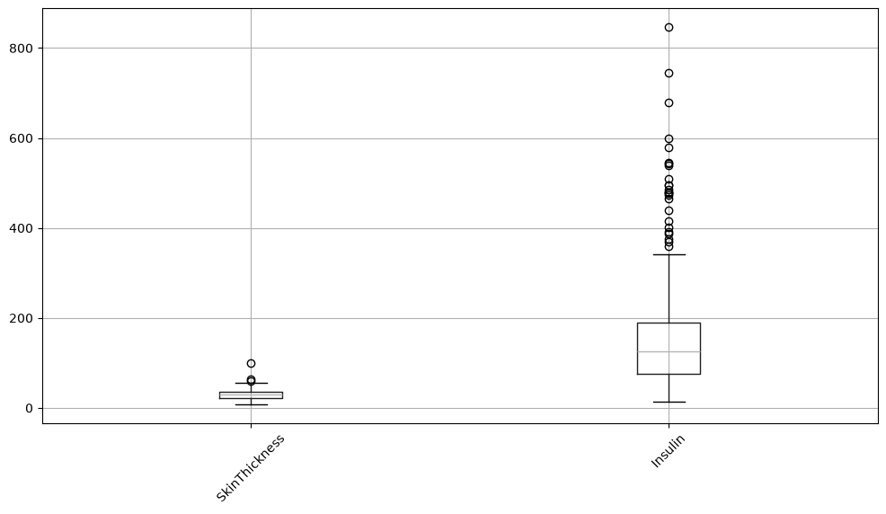

```python
diabetes_data[cols[2:-1]].boxplot(figsize=(12,6))
plt.xticks(rotation=45)
plt.show()
```

```python
diabetes_data["SkinThickness"] = diabetes_data["SkinThickness"].fillna(diabetes_data["SkinThickness"].mean())
#diabetes_data["Insulin"] = diabetes_data["Insulin"].fillna(diabetes_data["Insulin"].median())
diabetes_data[cols].isnull().mean() * 100
```

```
Glucose           0.000000
BloodPressure     0.000000
SkinThickness     0.000000
Insulin          45.856354
BMI               0.000000
dtype: float64
```

```python
diabetes_data.describe().T
```

|  | count | mean | std | min | 25% | 50% | 75% | max |
| --- | --- | --- | --- | --- | --- | --- | --- | --- |
| Pregnancies | 724.0 | 3.866022 | 3.362803 | 0.000 | 1.000 | 3.000000 | 6.0000 | 17.00 |
| Glucose | 724.0 | 121.882597 | 30.750030 | 44.000 | 99.750 | 117.000000 | 142.0000 | 199.00 |
| BloodPressure | 724.0 | 72.400552 | 12.379870 | 24.000 | 64.000 | 72.000000 | 80.0000 | 122.00 |
| SkinThickness | 724.0 | 29.182331 | 9.018907 | 7.000 | 25.000 | 29.182331 | 33.0000 | 99.00 |
| Insulin | 392.0 | 156.056122 | 118.841690 | 14.000 | 76.750 | 125.500000 | 190.0000 | 846.00 |
| BMI | 724.0 | 32.467127 | 6.888941 | 18.200 | 27.500 | 32.400000 | 36.6000 | 67.10 |
| DiabetesPedigreeFunction | 724.0 | 0.474765 | 0.332315 | 0.078 | 0.245 | 0.379000 | 0.6275 | 2.42 |
| Age | 724.0 | 33.350829 | 11.765393 | 21.000 | 24.000 | 29.000000 | 41.0000 | 81.00 |
| Outcome | 724.0 | 0.343923 | 0.475344 | 0.000 | 0.000 | 0.000000 | 1.0000 | 1.00 |

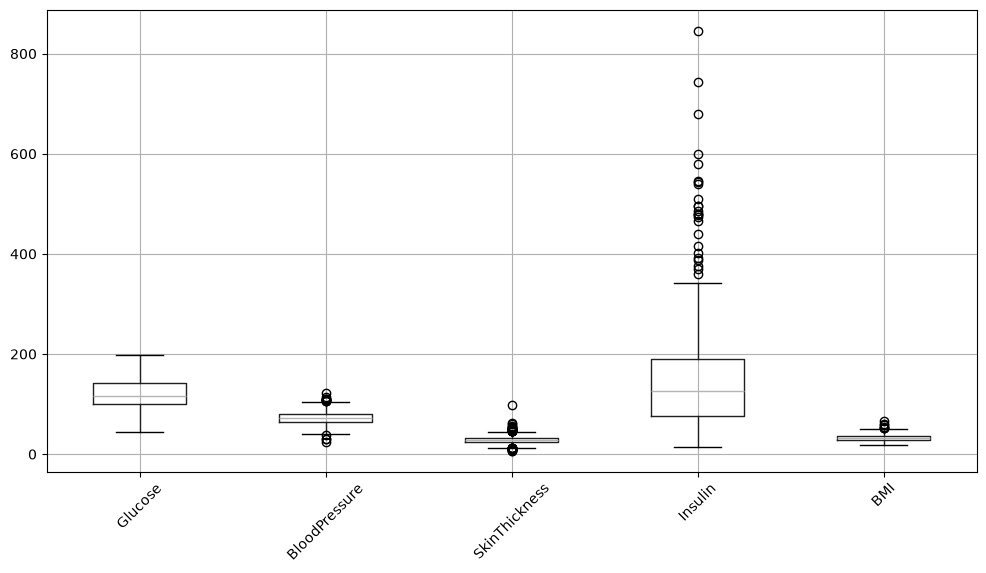

```python
diabetes_data[cols].boxplot( figsize = (12,6))
plt.xticks(rotation=45)
plt.show()
```

```python
diabetes_data['Insulin'].skew()
```

```
np.float64(2.165116186357338)
```

```python
x = diabetes_data.drop("Outcome", axis=1)
y = diabetes_data["Outcome"]

x_train, x_test, y_train, y_test = train_test_split(
    x,
    y,
    test_size = 0.2,
    random_state = 42,
    stratify = y # stratify to maintain class distribution in train/test split
)
```

```python
from sklearn.impute import KNNImputer
imputer = KNNImputer(n_neighbors=5)
```

```python
x_train_imputed = pd.DataFrame(
    imputer.fit_transform(x_train),
    columns= x_train.columns,
    index = x_train.index
)
x_test_imputed = pd.DataFrame(
    imputer.transform(x_test),
    columns= x_test.columns,
    index = x_test.index
)
```

```python
print("x_train_imputed is null values: \n")
print(x_train_imputed.isnull().sum())
print("\nx_test_imputed is null values: \n")
print(x_test_imputed.isnull().sum())
```

```
x_train_imputed is null values:

Pregnancies                 0
Glucose                     0
BloodPressure               0
SkinThickness               0
Insulin                     0
BMI                         0
DiabetesPedigreeFunction    0
Age                         0
dtype: int64

x_test_imputed is null values:

Pregnancies                 0
Glucose                     0
BloodPressure               0
SkinThickness               0
Insulin                     0
BMI                         0
DiabetesPedigreeFunction    0
Age                         0
dtype: int64
```

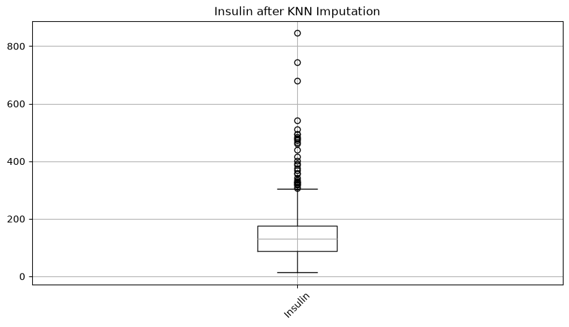

```python
plt.figure(figsize=(10, 5))
x_train_imputed.boxplot(column=["Insulin"])
plt.title("Insulin after KNN Imputation")
plt.xticks(rotation=45)
plt.show()
```

### now lets see each distribution of each feature to understand the data better and to find out if there is any skewness in the data

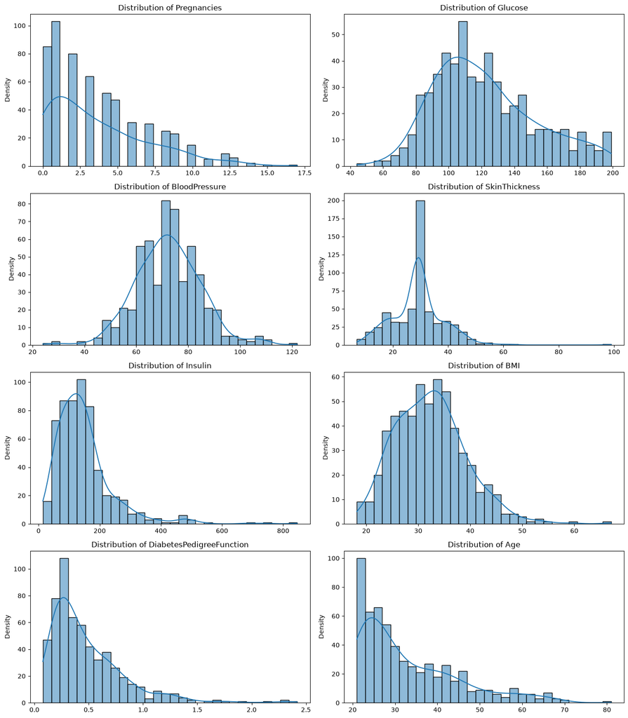

```python
import math

cols = x_train_imputed.columns

n = len(cols)

rows = math.ceil(n / 2)

fig, axes = plt.subplots(rows, 2, figsize=(14, 4 * rows))
axes = axes.ravel()

for i, col in enumerate(cols):
    sns.histplot(
        x_train_imputed[col],
        kde=True,
        bins=30,
        ax=axes[i]
    )

    axes[i].set_title(f"Distribution of {col}")
    axes[i].set_xlabel("")
    axes[i].set_ylabel("Density")

# Hide extra empty subplots (safe way)
for j in range(n, len(axes)):
    axes[j].set_visible(False)

plt.tight_layout()
plt.show()
```

# 📊 Skewness Analysis of Features (Diabetes Dataset)

## 🔴 Right-Skewed Features (Positive Skew)

These features have a long tail on the **right side**, meaning most values are small with a few very large values:

- Pregnancies → right-skewed
- Glucose → slightly right-skewed
- BMI → slightly right-skewed
- DiabetesPedigreeFunction → heavily right-skewed
- Age → heavily right-skewed
- Insulin → heavily right-skewed

## 🟡 Approximately Normal / Near Symmetric

These features are closer to a normal distribution but not perfectly symmetric:

- BloodPressure → approximately normal
- SkinThickness → approximately normal (slight skew may exist)

## 🧠 Key Insight

- Most features in this dataset are **right-skewed**
- Very few features follow a normal distribution
- This is common in real-world medical datasets

## 🚀 Why This Matters

Skewness affects machine learning preprocessing:

### For right-skewed features:

- Log transformation (`log1p`)
- Robust scaling

### For near-normal features:

- StandardScaler works well

## 💡 Conclusion

The dataset contains a mix of:

- Strongly right-skewed features (Age, Insulin, DiabetesPedigreeFunction)
- Mildly skewed features (Glucose, BMI)
- Near-normal features (BloodPressure, SkinThickness)

Understanding this helps in choosing the right preprocessing strategy before model training.

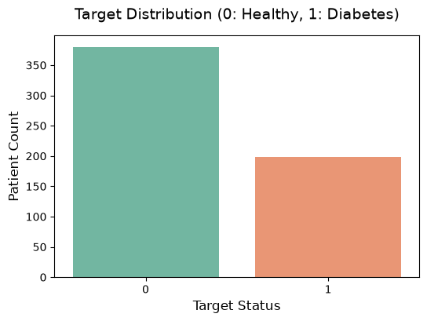

```python
plt.figure(figsize=(6, 4))
ax = sns.countplot(x=y_train, data=x_train_imputed, hue=y_train, palette="Set2", legend=False)
plt.title("Target Distribution (0: Healthy, 1: Diabetes)", fontsize=14, pad=15)
plt.xlabel("Target Status", fontsize=12)
plt.ylabel("Patient Count", fontsize=12)

plt.show()
```

```python
y_train.value_counts(normalize=True) * 100
```

```
Outcome
0    65.630397
1    34.369603
Name: proportion, dtype: float64
```

### Target Variable Distribution

- The dataset contains more healthy patients (`Outcome = 0`) than diabetic patients (`Outcome = 1`).
- Approximately **65%** of the observations belong to the healthy class, while **35%** belong to the diabetic class.
- This indicates that the dataset is **moderately imbalanced**.
- Since the imbalance is not extremely severe (roughly 2:1), many machine learning algorithms can still perform well. However, evaluation metrics such as **Precision, Recall, F1-score, and ROC-AUC** should be considered in addition to accuracy.

## now we check the correlation of each feature with the target variable to find out which feature is more important in predicting diabetes

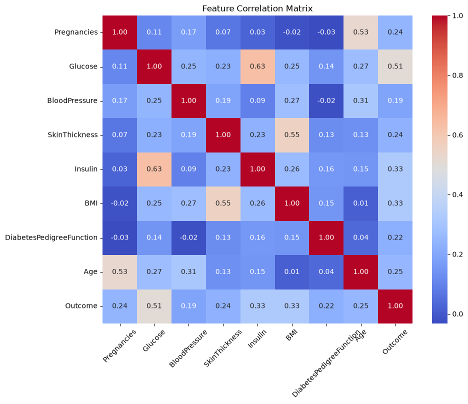

```python
train_data =x_train_imputed.copy()
train_data["Outcome"] = y_train
plt.figure(figsize=(10, 8))
sns.heatmap(train_data.corr(), annot=True, fmt=".2f", cmap="coolwarm")
plt.title("Feature Correlation Matrix")
plt.xticks(rotation=45)
plt.show()
```

```python
# for tetsing as got 0 in correlation between glucose and outcome
print(x_train_imputed.shape)
print(y_train.shape)

print(x_train_imputed.index[:5])
print(y_train.index[:5])
```

```
(579, 8)
(579,)
Index([200, 4, 394, 436, 581], dtype='int64')
Index([200, 4, 394, 436, 581], dtype='int64')
```

## Feature-Target Correlation Analysis

| Feature | Correlation | Strength |
| --- | --- | --- |
| Glucose | 0.51 | Moderate-High |
| Insulin | 0.33 | Moderate |
| BMI | 0.33 | Moderate |
| Age | 0.25 | Low-Moderate |
| Pregnancies | 0.24 | Low-Moderate |
| SkinThickness | 0.24 | Low-Moderate |
| DiabetesPedigreeFunction | 0.22 | Low-Moderate |
| BloodPressure | 0.19 | Low |

*Correlations computed on training set only (post train/test split) to avoid data leakage.*

## Key Insights

### Strong Signal

- Glucose is the strongest individual predictor (0.51), which aligns with medical knowledge — high blood sugar is a defining characteristic of diabetes.

### Moderate Contributors

- Insulin and BMI are tied as the second strongest predictors (0.33 each). Clinically this makes sense: insulin resistance and obesity are core diabetes risk factors.

### Low-Moderate Contributors

- Age (0.25), Pregnancies (0.24), SkinThickness (0.24), and DiabetesPedigreeFunction (0.22) all fall in the same low-moderate range. Each has clinical grounding (age-related risk, gestational history, adiposity proxy, and genetic predisposition respectively).

### Weakest Predictor

- BloodPressure (0.19) is the only feature in the Low category and the only one without clear boxplot separation between classes. Still retained — it may contribute through interaction effects with other features.

## Important Caveat

Linear correlation only captures LINEAR relationships. These features may have non-linear relationships with the target that a model like Random Forest would capture but Pearson correlation would miss.

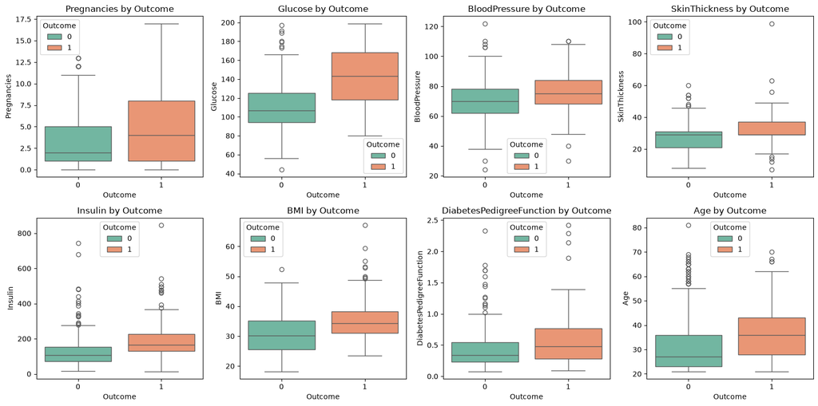

```python
fig, axes = plt.subplots(2, 4, figsize=(16, 8))
axes = axes.ravel()

features = x_train_imputed.columns
for i, col in enumerate(features):
    sns.boxplot(
        x="Outcome",
        y=col,
        data=train_data,
        hue="Outcome",
        ax=axes[i],
        palette="Set2"
    )
    axes[i].set_title(f"{col} by Outcome")

plt.tight_layout()
plt.show()
```

## Feature Importance Summary

### Tier 1 - Strong Predictors

- Glucose (0.51): Highest correlation + clear boxplot separation. Clinically valid — high blood sugar defines diabetes.
- Pregnancies (0.24): Low-moderate correlation but clear median separation in boxplot. Clinically valid — gestational diabetes risk increases with more pregnancies.
- Age (0.25): Clear median separation in boxplot. Clinically valid — older age increases Type 2 diabetes risk.

### Tier 2 - Moderate Predictors

- Insulin (0.33): 2nd strongest correlation (tied with BMI). After correcting for data leakage (train/test split before KNN imputation), boxplot now shows visible median separation between classes. Outlier influence still under investigation — separation may become clearer when extreme values are excluded.
- BMI (0.33): Tied 2nd strongest correlation. Obesity is a core diabetes risk factor — important feature.

### Tier 3 - Weak Individual Predictors

- DiabetesPedigreeFunction (0.22): Weak linear correlation but encodes genetic history — likely has non-linear importance.
- SkinThickness (0.24): Weak predictor individually, but shows median separation in boxplot.
- BloodPressure (0.19): Only feature with no clear median separation in boxplot after re-imputation. Weakest visual and statistical predictor. Retained as it may contribute in combination with other features.

## Key Conclusion

No single feature will be dropped. After re-running EDA with a proper train/test split before KNN imputation (eliminating leakage risk), most features show meaningful median separation between classes — BloodPressure being the sole exception. Even weak individual predictors may contribute through:

1. Interaction effects with other features
2. Non-linear relationships (captured by tree-based models like Random Forest)
3. Combined pattern recognition in the model

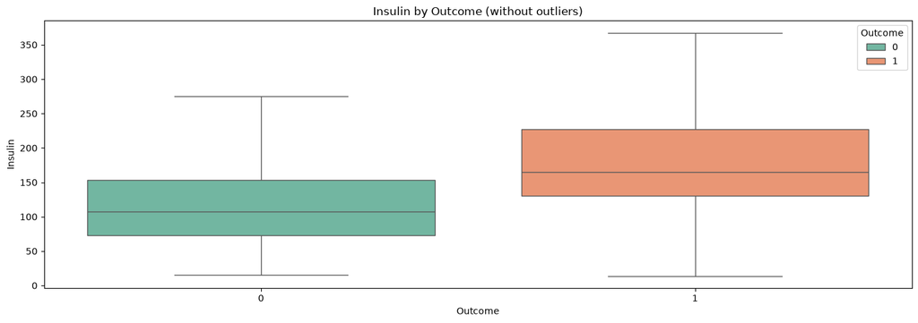

```python
fig, axes = plt.subplots(1, 1, figsize=(14, 5))
sns.boxplot(
    x="Outcome", y="Insulin",
    data=train_data, hue="Outcome",
    ax=axes, palette="Set2",
    showfliers=False          # ← hides outlier points
)
axes.set_title("Insulin by Outcome (without outliers)")

plt.tight_layout()
plt.show()
```

## Insulin - Revised Assessment

### Assessment

"Insulin shows a meaningful median separation (~50 units) between healthy and diabetic patients that was initially hidden by extreme outliers.

When visualized without outliers, insulin emerges as a MODERATE predictor of diabetes, consistent with its correlation of 0.33.

Key characteristics:

- Real median separation exists (~110 vs ~160)
- High variance due to biological variability
- Large number of outliers in both groups
- Still weaker than Glucose (0.51)"

## after commpletion of EDA, we do pre-Processing

since we have found that most feature are right skewed as well as huge number out outlier, we use the method of log transformation to make the data more normal and to reduce the effect of outliers in the data.

```python
def transform_features(df):
    skewed_cols  = ["Pregnancies", "Insulin",
               "DiabetesPedigreeFunction", "Age"]
    df_transformed = df.copy()
    df_transformed[skewed_cols] = df_transformed[skewed_cols ].apply(lambda x: np.log1p(x))
    # Verify skewness reduced
    print("Before transformation:")
    print(df[skewed_cols].skew().round(2))

    print("\nAfter transformation:")
    print(df_transformed[skewed_cols].skew().round(2))
    return df_transformed, skewed_cols
```

```python
x_train_imputed_transformed, skewed_cols = transform_features(x_train_imputed)
```

```
Before transformation:
Pregnancies                 1.02
Insulin                     2.49
DiabetesPedigreeFunction    1.99
Age                         1.22
dtype: float64

After transformation:
Pregnancies                -0.21
Insulin                    -0.17
DiabetesPedigreeFunction    1.17
Age                         0.68
dtype: float64
```

```python
x_test_imputed_transformed, _ = transform_features(x_test_imputed)
```

```
Before transformation:
Pregnancies                 0.50
Insulin                     1.99
DiabetesPedigreeFunction    1.15
Age                         0.64
dtype: float64

After transformation:
Pregnancies                -0.42
Insulin                    -0.16
DiabetesPedigreeFunction    0.73
Age                         0.26
dtype: float64
```

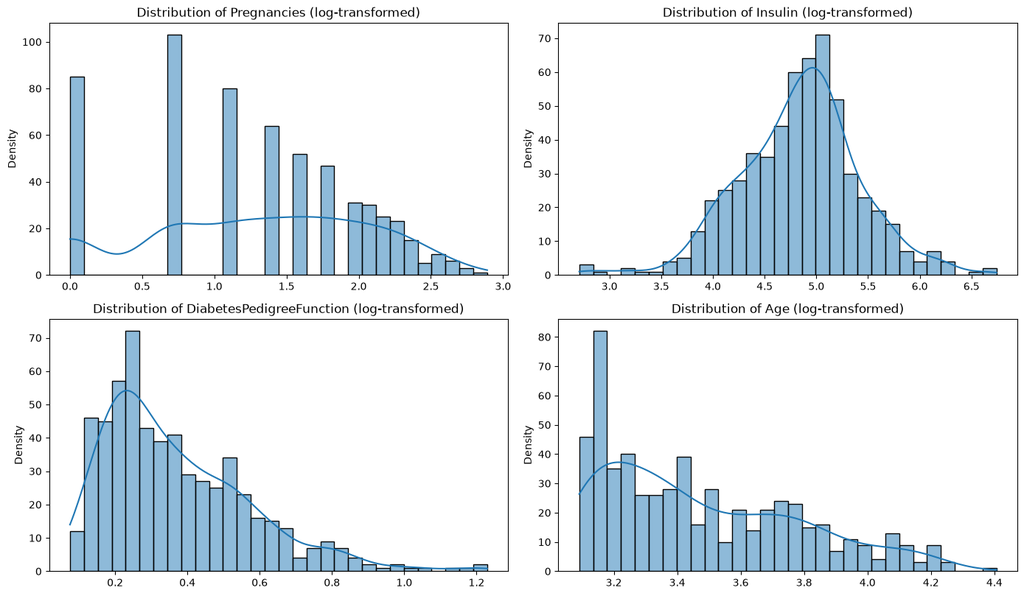

```python
row = len(skewed_cols)

fig, axes = plt.subplots(row, 2, figsize = (14, 4 * row ))
axes = axes.ravel()

for i, col in enumerate(skewed_cols):
    sns.histplot(
        x_train_imputed_transformed[col],
        kde= True,
        bins=30,
        ax=axes[i]
    )

    axes[i].set_title(f"Distribution of {col} (log-transformed)")
    axes[i].set_xlabel("")
    axes[i].set_ylabel("Density")

# Hide extra empty subplots (safe way)
for j in range(row, len(axes)):
    axes[j].set_visible(False)

plt.tight_layout()
plt.show()
```

## Log Transformation Analysis

### Results

Log transformation had mixed effectiveness across features:

- **Insulin**: Most improved — skewness reduced from 2.49 to -0.17, now close to normal distribution.
- **DiabetesPedigreeFunction**: Meaningful improvement (1.99 → 1.17) but still moderately right-skewed.
- **Age**: Partial improvement (1.22 → 0.68) but distribution shows multiple peaks, likely reflecting distinct age subgroups in the data.
- **Pregnancies**: Over-corrected into slight left skew (1.02 → -0.21). Multiple peaks persist, suggesting discrete subgroups (e.g., 0, 1-2, 3+ pregnancies) that log transformation cannot smooth out.

### Skewness Summary

| Feature | Before | After |
| --- | --- | --- |
| Pregnancies | 1.02 | -0.21 |
| Insulin | 2.49 | -0.17 |
| DiabetesPedigreeFunction | 1.99 | 1.17 |
| Age | 1.22 | 0.68 |

### Key Takeaway

Log transformation is effective for Insulin but limited for the other features. The multimodal distributions in Age and Pregnancies reflect genuine data subgroups rather than simple skewness — a different transformation is unlikely to resolve this. Since tree-based models (Random Forest, Gradient Boosting) are scale and distribution agnostic, residual skewness in these features is unlikely to harm model performance.

```python
def add_features(df_transformed, df_original):
    # Use original scale values - clinically meaningful
    df_transformed['Glucose_Insulin_Ratio'] = (
    df_original['Glucose'] / (df_original['Insulin'] + 1)
    )

    df_transformed['BMI_Age'] = (
    df_original['BMI'] * df_original['Age']
    )

    df_transformed['High_Glucose'] = (
    df_original['Glucose'] > 140
    ).astype(int)
```

```python
# Use original scale values - clinically meaningful
add_features(x_train_imputed_transformed, x_train_imputed)
add_features(x_test_imputed_transformed, x_test_imputed)
```

```python
x_train_imputed_transformed.head()
```

|  | Pregnancies | Glucose | BloodPressure | SkinThickness | Insulin | BMI | DiabetesPedigreeFunction | Age | Glucose_Insulin_Ratio | BMI_Age | High_Glucose |
| --- | --- | --- | --- | --- | --- | --- | --- | --- | --- | --- | --- |
| 200 | 0.000000 | 113.0 | 80.0 | 16.000000 | 4.497585 | 31.0 | 0.628075 | 3.091042 | 1.258352 | 651.0 | 0 |
| 4 | 0.000000 | 137.0 | 40.0 | 35.000000 | 5.129899 | 43.1 | 1.190279 | 3.526361 | 0.810651 | 1422.3 | 0 |
| 394 | 1.609438 | 158.0 | 78.0 | 29.182331 | 5.572154 | 32.9 | 0.589452 | 3.465736 | 0.600760 | 1019.9 | 1 |
| 436 | 2.564949 | 140.0 | 85.0 | 33.000000 | 4.888844 | 37.4 | 0.218332 | 3.737670 | 1.054217 | 1533.4 | 0 |
| 581 | 1.945910 | 109.0 | 60.0 | 27.000000 | 4.782479 | 25.0 | 0.187309 | 3.332205 | 0.912898 | 675.0 | 0 |

## Feature Engineering

Logistic Regression and SVM are linear/kernel-based models — they benefit greatly from explicitly encoded relationships between features. However, diabetes risk often depends on **combinations** of features, not just individual values.

For example:

- High glucose alone may not indicate diabetes if insulin is also appropriately high
- High BMI is more dangerous in older patients than younger ones

Manually creating features that encode these combinations helps the models capture interactions they would otherwise miss or require many more iterations to approximate.

These features will be tested across all candidate models (Logistic Regression, KNN, SVM, SGD). The best 1-2 performers will then be selected for hyperparameter tuning.

```python
# Verify stratification worked
print("\nTrain target distribution:")
print(y_train.value_counts(normalize=True).round(3))
print("\nTest target distribution:")
print(y_test.value_counts(normalize=True).round(3))
```

```
Train target distribution:
Outcome
0    0.656
1    0.344
Name: proportion, dtype: float64

Test target distribution:
Outcome
0    0.655
1    0.345
Name: proportion, dtype: float64
```

## feature scaling , we use StandardScaler, as it is common method to scale the data

```python
from sklearn.linear_model import LogisticRegression, SGDClassifier
from sklearn.svm import SVC
from sklearn.neighbors import KNeighborsClassifier
from sklearn.calibration import CalibratedClassifierCV

models = {
    'Logistic Regression': LogisticRegression(random_state=42, max_iter=1000),
    'KNN':                 KNeighborsClassifier(),
    'SVM (RBF kernel)':    CalibratedClassifierCV(SVC(random_state=42), cv=5),
    'SGD Classifier':      SGDClassifier(loss='log_loss', random_state=42, max_iter=1000)
}

result = []

for name, model in models.items():
    pip = Pipeline([
        ('scaler', StandardScaler()),
        ('model', model)
    ])

    pip.fit(x_train_imputed_transformed, y_train)

    y_pred = pip.predict(x_test_imputed_transformed)
    y_prob = pip.predict_proba(x_test_imputed_transformed)[:, 1]

    result.append({
        "model": name,
        "accuracy_score": round(accuracy_score(y_test, y_pred), 2),
        "precision_score": round(precision_score(y_test, y_pred), 2),
        "recall_score": round(recall_score(y_test, y_pred), 2),

    })

results_df = pd.DataFrame(result)
results_df
```

|  | model | accuracy_score | precision_score | recall_score |
| --- | --- | --- | --- | --- |
| 0 | Logistic Regression | 0.72 | 0.60 | 0.58 |
| 1 | KNN | 0.69 | 0.55 | 0.58 |
| 2 | SVM (RBF kernel) | 0.74 | 0.62 | 0.60 |
| 3 | SGD Classifier | 0.66 | 0.51 | 0.46 |

## Model Selection Analysis

### Baseline Results (Default Parameters)

After training four candidate models on the same dataset, the following results were observed:

| Model | Accuracy | Precision | Recall |
| --- | --- | --- | --- |
| Logistic Regression | 0.72 | 0.60 | 0.58 |
| KNN | 0.69 | 0.55 | 0.58 |
| SVM (RBF Kernel) | 0.74 | 0.62 | 0.60 |
| SGD Classifier | 0.66 | 0.51 | 0.46 |

### Why Recall Is Our Primary Metric

In a medical classification problem, **not all errors are equal**.

- A **False Negative** (predicting non-diabetic when the patient is diabetic) means a sick patient goes undiagnosed and untreated — a serious clinical risk.
- A **False Positive** (predicting diabetic when the patient is not) leads to further testing — inconvenient but not harmful.

Therefore, we prioritize **Recall on the diabetic class (class 1)** over overall accuracy. A model that scores high accuracy by mostly predicting class 0 is not useful in healthcare.

### Model Elimination

**SGD Classifier — Eliminated**

- Recall : 0.46 — worst among all models.
- This means SGD missed 54% of actual diabetic patients, making it clinically unreliable.
- Its lower accuracy (0.66) and precision (0.51) further confirm it is not suitable.

**KNN — Deprioritized**

- Recall : 0.58 — tied with Logistic Regression but lower accuracy (0.69) and lower precision (0.55).
- Not eliminated, but SVM and Logistic Regression are stronger candidates.

### Remaining Candidates

**SVM (RBF Kernel)** — Best overall: highest accuracy (0.74), precision (0.62), and recall (0.60).

**Logistic Regression** — Close second: slightly lower across all metrics but more interpretable and faster to tune.

These two will proceed to hyperparameter tuning.

## hyper parameter tuning for svm and logistic regresstion

```python
# for svm
svm_pipe = Pipeline([
    ("scaler", StandardScaler()),
    ("model", CalibratedClassifierCV(estimator=SVC(random_state=42),
        cv=5))
])

svm_parms = {
    'model__estimator__C':     [0.1, 1, 10, 100],
    'model__estimator__gamma': ['scale', 'auto', 0.01, 0.1],

}

svm_grid = GridSearchCV(svm_pipe, svm_parms, cv=5, scoring="roc_auc", n_jobs= -1)
svm_grid.fit(x_train_imputed_transformed, y_train)

print("Best SVM Parameters:", svm_grid.best_params_)
print("Best SVM ROC AUC : ", round(svm_grid.best_score_, 2))
```

```
Best SVM Parameters: {'model__estimator__C': 1, 'model__estimator__gamma': 0.01}
Best SVM ROC AUC :  0.85
```

```python
# logistic regression hyperparameter tuning
lr_pip = Pipeline([
    ("scaler", StandardScaler()),
    ("model", LogisticRegression(random_state=42, max_iter=1000))
])

lr_parms = {
    'model__C': [0.01, 0.1, 1, 10, 100]
}

lr_grid = GridSearchCV(lr_pip, lr_parms, cv=5, scoring="roc_auc", n_jobs=1)

lr_grid.fit(x_train_imputed_transformed, y_train)

print("Best Logistric Regression Parameters: ", lr_grid.best_params_)
print("Best Logistric Regression ROC AUC: ", round(lr_grid.best_score_, 2))
```

```
Best Logistric Regression Parameters:  {'model__C': 100}
Best Logistric Regression ROC AUC:  0.85
```

```
==================================================
Logistic Regression - Test Set Evaluation
==================================================
              precision    recall  f1-score   support

           0       0.79      0.81      0.80        95
           1       0.62      0.60      0.61        50

    accuracy                           0.74       145
   macro avg       0.71      0.71      0.71       145
weighted avg       0.74      0.74      0.74       145

ROC-AUC: 0.768
```

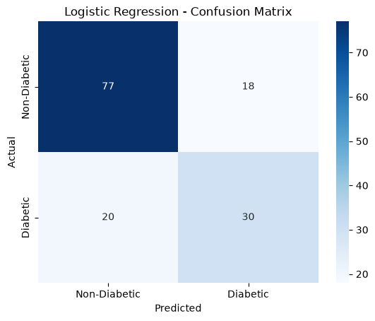

```
==================================================
SVM - Test Set Evaluation
==================================================
              precision    recall  f1-score   support

           0       0.78      0.84      0.81        95
           1       0.65      0.56      0.60        50

    accuracy                           0.74       145
   macro avg       0.72      0.70      0.71       145
weighted avg       0.74      0.74      0.74       145

ROC-AUC: 0.755
```

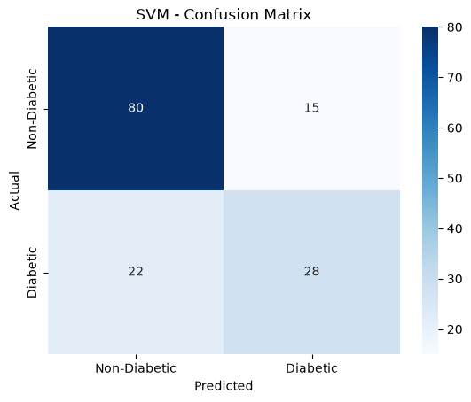

```python
from sklearn.metrics import classification_report, roc_auc_score, confusion_matrix
import seaborn as sns
import matplotlib.pyplot as plt

for name, grid in [('Logistic Regression', lr_grid), ('SVM', svm_grid)]:
    best_model = grid.best_estimator_
    y_pred     = best_model.predict(x_test_imputed_transformed)
    y_prob     = best_model.predict_proba(x_test_imputed_transformed)[:, 1]

    print(f"\n{'='*50}")
    print(f"{name} - Test Set Evaluation")
    print(f"{'='*50}")
    print(classification_report(y_test, y_pred))
    print("ROC-AUC:", round(roc_auc_score(y_test, y_prob), 3))

    # Confusion Matrix
    cm = confusion_matrix(y_test, y_pred)
    sns.heatmap(cm, annot=True, fmt='d', cmap='Blues',
                xticklabels=['Non-Diabetic', 'Diabetic'],
                yticklabels=['Non-Diabetic', 'Diabetic'])
    plt.title(f'{name} - Confusion Matrix')
    plt.ylabel('Actual')
    plt.xlabel('Predicted')
    plt.show()
```

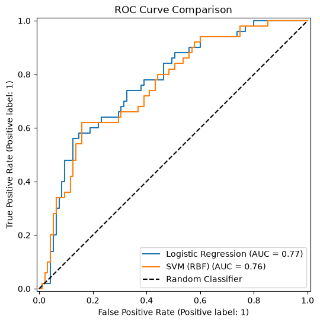

```python
from sklearn.metrics import RocCurveDisplay
import matplotlib.pyplot as plt

fig, ax = plt.subplots(figsize=(8, 6))

RocCurveDisplay.from_estimator(
    lr_grid.best_estimator_, x_test_imputed_transformed, y_test,
    name='Logistic Regression', ax=ax
)

RocCurveDisplay.from_estimator(
    svm_grid.best_estimator_, x_test_imputed_transformed, y_test,
    name='SVM (RBF)', ax=ax
)

ax.plot([0, 1], [0, 1], 'k--', label='Random Classifier')
ax.set_title('ROC Curve Comparison')
ax.legend()
plt.show()
```

## ROC Curve Comparison

The ROC (Receiver Operating Characteristic) curve plots True Positive Rate (Recall) against False Positive Rate across all possible classification thresholds.

A perfect model scores AUC = 1.0. A random classifier scores 0.5 (the diagonal). The closer the curve hugs the top-left corner, the better the model's discriminative ability — independent of any threshold choice.

| Model | ROC-AUC |
| --- | --- |
| Logistic Regression | 0.768 |
| SVM (RBF Kernel) | 0.755 |

Logistic Regression edges out SVM in overall discriminative ability. Both models perform significantly better than random chance (0.5 baseline). The curves track closely throughout, confirming neither model dominates clearly — threshold tuning will be the deciding factor.

```python
from sklearn.model_selection import cross_val_score

cv_scores = cross_val_score(
    svm_grid.best_estimator_, x_train_imputed_transformed, y_train,
    cv=5, scoring='roc_auc'
)

print("CV ROC-AUC Scores:", cv_scores.round(3))
print("Mean:", cv_scores.mean().round(3))
print("Std:", cv_scores.std().round(3))
```

```
CV ROC-AUC Scores: [0.879 0.843 0.837 0.852 0.816]
Mean: 0.845
Std: 0.021
```

## Cross-Validation — Model Stability Check

A single train/test split can be misleading — the model might perform well or poorly simply due to how the data happened to be split. Cross-validation trains and evaluates the model across 5 different splits to check whether performance is consistent.

CV ROC-AUC Scores: [0.879, 0.843, 0.837, 0.852, 0.816] Mean ROC-AUC: 0.845 Std Deviation: 0.021

```python
# ── Threshold Optimization ──────────────────────────────
# Default threshold (0.5) prioritizes overall accuracy.
# In diabetes screening, missing a diabetic patient (False Negative)
# is far more dangerous than a false alarm.
# We tune the threshold to maximize diabetic recall while keeping
# precision acceptable.

from sklearn.metrics import precision_recall_curve

best_model = lr_grid.best_estimator_
y_prob = best_model.predict_proba(x_test_imputed_transformed)[:, 1]

precisions, recalls, thresholds = precision_recall_curve(y_test, y_prob)

# Find threshold where diabetic recall >= 0.80
target_recall = 0.80
viable = [(t, p, r) for t, p, r in zip(thresholds, precisions[:-1], recalls[:-1])
          if r >= target_recall]

if viable:
    best_threshold, best_precision, best_recall = max(viable, key=lambda x: x[1])
    print(f"Threshold: {best_threshold:.3f}")
    print(f"Diabetic Recall:    {best_recall:.3f}")
    print(f"Diabetic Precision: {best_precision:.3f}")
```

```
Threshold: 0.225
Diabetic Recall:    0.840
Diabetic Precision: 0.488
```

```python
# ── Apply the New Threshold ────────────────────────────
y_pred_tuned = (y_prob >= best_threshold).astype(int)

print(classification_report(y_test, y_pred_tuned))
print("ROC-AUC:", round(roc_auc_score(y_test, y_prob), 3))
```

```
              precision    recall  f1-score   support

           0       0.86      0.54      0.66        95
           1       0.49      0.84      0.62        50

    accuracy                           0.64       145
   macro avg       0.68      0.69      0.64       145
weighted avg       0.73      0.64      0.65       145

ROC-AUC: 0.768
```

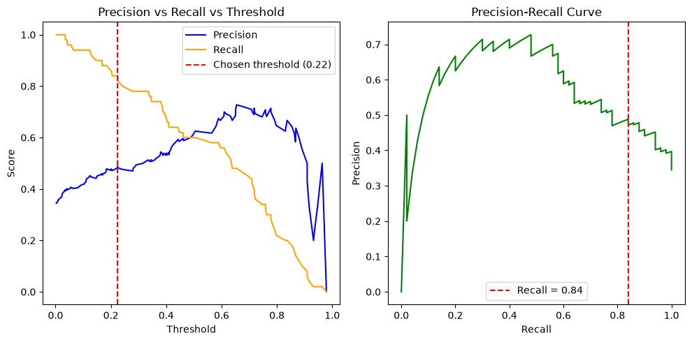

```python
# ── Visualize Precision-Recall Tradeoff ───────────────
plt.figure(figsize=(10, 5))

plt.subplot(1, 2, 1)
plt.plot(thresholds, precisions[:-1], label='Precision', color='blue')
plt.plot(thresholds, recalls[:-1],    label='Recall',    color='orange')
plt.axvline(x=best_threshold, color='red', linestyle='--', label=f'Chosen threshold ({best_threshold:.2f})')
plt.xlabel('Threshold')
plt.ylabel('Score')
plt.title('Precision vs Recall vs Threshold')
plt.legend()

plt.subplot(1, 2, 2)
plt.plot(recalls[:-1], precisions[:-1], color='green')
plt.axvline(x=best_recall, color='red', linestyle='--', label=f'Recall = {best_recall:.2f}')
plt.xlabel('Recall')
plt.ylabel('Precision')
plt.title('Precision-Recall Curve')
plt.legend()

plt.tight_layout()
plt.show()
```

```python
# Find threshold where diabetic recall >= 0.70
target_recall = 0.70
viable = [(t, p, r) for t, p, r in zip(thresholds, precisions[:-1], recalls[:-1])
          if r >= target_recall]

if viable:
    best_threshold, best_precision, best_recall = max(viable, key=lambda x: x[1])
    print(f"Threshold: {best_threshold:.3f}")
    print(f"Diabetic Recall:    {best_recall:.3f}")
    print(f"Diabetic Precision: {best_precision:.3f}")
```

```
Threshold: 0.380
Diabetic Recall:    0.740
Diabetic Precision: 0.544
```

```python
# ── Apply the New Threshold ────────────────────────────
y_pred_tuned = (y_prob >= best_threshold).astype(int)

print(classification_report(y_test, y_pred_tuned))
print("ROC-AUC:", round(roc_auc_score(y_test, y_prob), 3))
```

```
              precision    recall  f1-score   support

           0       0.83      0.67      0.74        95
           1       0.54      0.74      0.63        50

    accuracy                           0.70       145
   macro avg       0.69      0.71      0.69       145
weighted avg       0.73      0.70      0.70       145

ROC-AUC: 0.768
```

```python
# ── Threshold Optimization ──────────────────────────────
# Default threshold (0.5) prioritizes overall accuracy.
# In diabetes screening, missing a diabetic patient (False Negative)
# is far more dangerous than a false alarm.
# We tune the threshold to maximize diabetic recall while keeping
# precision acceptable.



best_model = svm_grid.best_estimator_
y_prob = best_model.predict_proba(x_test_imputed_transformed)[:, 1]

precisions, recalls, thresholds = precision_recall_curve(y_test, y_prob)

# Find threshold where diabetic recall >= 0.80
target_recall = 0.80
viable = [(t, p, r) for t, p, r in zip(thresholds, precisions[:-1], recalls[:-1])
          if r >= target_recall]

if viable:
    best_threshold, best_precision, best_recall = max(viable, key=lambda x: x[1])
    print(f"Threshold: {best_threshold:.3f}")
    print(f"Diabetic Recall:    {best_recall:.3f}")
    print(f"Diabetic Precision: {best_precision:.3f}")
```

```
Threshold: 0.256
Diabetic Recall:    0.800
Diabetic Precision: 0.488
```

```python
y_prob_svm = svm_grid.best_estimator_.predict_proba(x_test_imputed_transformed)[:, 1]
threshold  = 0.234
y_pred_adj = (y_prob_svm >= threshold).astype(int)

print(classification_report(y_test, y_pred_adj))
print("ROC-AUC:", round(roc_auc_score(y_test, y_prob_svm), 3))
```

```
              precision    recall  f1-score   support

           0       0.83      0.52      0.64        95
           1       0.47      0.80      0.59        50

    accuracy                           0.61       145
   macro avg       0.65      0.66      0.61       145
weighted avg       0.70      0.61      0.62       145

ROC-AUC: 0.755
```

```python
# Find threshold where diabetic recall >= 0.80
target_recall = 0.70
viable = [(t, p, r) for t, p, r in zip(thresholds, precisions[:-1], recalls[:-1])
          if r >= target_recall]

if viable:
    best_threshold, best_precision, best_recall = max(viable, key=lambda x: x[1])
    print(f"Threshold: {best_threshold:.3f}")
    print(f"Diabetic Recall:    {best_recall:.3f}")
    print(f"Diabetic Precision: {best_precision:.3f}")
    print(f"accuracy_score: {accuracy_score(y_test, (y_prob_svm >= best_threshold).astype(int)):.3f}")
```

```
Threshold: 0.278
Diabetic Recall:    0.720
Diabetic Precision: 0.493
accuracy_score: 0.648
```

## Threshold Tuning — Why This Matters Clinically

### The Problem with Default Threshold (0.50)

Machine learning classifiers output a **probability score** between 0 and 1 for each patient. By default, sklearn labels a patient as diabetic only if that probability is ≥ 0.50. This treats false positives and false negatives as equally costly.

In diabetes screening, they are not equal:

| Error Type | What Happens | Clinical Impact |
| --- | --- | --- |
| False Negative (missed diabetic) | Patient told they are healthy | No treatment → serious long-term harm |
| False Positive (incorrect flag) | Patient flagged for follow-up | Additional testing → inconvenient, not harmful |

At threshold 0.50, Logistic Regression misses 40% and SVM misses 44% of actual diabetic patients. In a real screening program, this is clinically unacceptable.

### The Solution — Lower the Threshold

By lowering the threshold, we flag more patients as diabetic. This deliberately increases false positives in order to reduce the more dangerous false negatives. This is not a model fix — it is a **conscious clinical decision** about how to deploy the model responsibly.

## Threshold Analysis — Both Models Evaluated

We evaluated both Logistic Regression and SVM across multiple thresholds to find the optimal operating point for each.

### Logistic Regression

| Threshold | Recall (Diabetic) | Precision (Diabetic) | Accuracy |
| --- | --- | --- | --- |
| 0.50 (default) | 0.60 | 0.62 | 0.74 |
| 0.380 | 0.74 | 0.54 | 0.70 |
| 0.225 | 0.84 | 0.49 | 0.64 |

### SVM (RBF Kernel)

| Threshold | Recall (Diabetic) | Precision (Diabetic) | Accuracy |
| --- | --- | --- | --- |
| 0.50 (default) | 0.56 | 0.65 | 0.74 |
| 0.278 | 0.72 | 0.49 | 0.648 |
| 0.234 | 0.80 | 0.47 | 0.61 |

## Model Comparison at Optimal Thresholds

| Metric | LR (threshold 0.380) | SVM (threshold 0.234) |
| --- | --- | --- |
| Recall (Diabetic) | 0.74 | **0.80** |
| Precision (Diabetic) | **0.54** | 0.47 |
| F1 (Diabetic) | **0.63** | 0.59 |
| Accuracy | **0.70** | 0.61 |
| ROC-AUC | **0.768** | 0.755 |

## Final Decision — Logistic Regression at Threshold 0.380

**Logistic Regression at threshold 0.380 is selected as the final model.**

### Why Logistic Regression Wins

This model is a **first-line screening tool**, not a diagnostic tool. The primary objective is to minimize missed diabetic cases — but precision cannot be ignored entirely. A model wrong on the majority of its positive predictions undermines clinical trust in the flagging system.

Given this context, the tradeoff favors Logistic Regression:

- LR retains **precision above 0.50** (0.54) — the model is still correct more often than not when flagging a patient as diabetic
- SVM at 0.234 drops precision to 0.47 — meaning the majority of patients flagged as diabetic are actually healthy, which is clinically hard to justify
- LR achieves **better F1** (0.63 vs 0.59), **higher accuracy** (0.70 vs 0.61), and **stronger ROC-AUC** (0.768 vs 0.755)
- LR recall of 0.74 means 37 out of 50 diabetic patients are correctly identified — a **14 percentage point improvement** over the default threshold

SVM's higher recall (0.80) comes at the cost of tipping precision below 0.50, which is not a tradeoff worth making when LR already delivers strong recall with better performance across every other metric.

### Important Limitation

Neither model should be used as a standalone diagnostic tool. All patients flagged as diabetic must be referred for confirmatory clinical testing — HbA1c measurement, fasting glucose test, or oral glucose tolerance test (OGTT) — before any diagnosis is made.

This model's role is to **prioritize who needs urgent evaluation**, not to replace clinical judgment.

```python
import pandas as pd


# Get feature names
feature_names = x_train_imputed_transformed.columns.tolist()

# Logistic Regression coefficients
lr_model = lr_grid.best_estimator_.named_steps['model']
lr_coefs = pd.DataFrame({
    'Feature': feature_names,
    'Coefficient': lr_model.coef_[0]
}).sort_values('Coefficient', ascending=False)

print("=== Logistic Regression Feature Importance ===")
print(lr_coefs.to_string(index=False))
```

```
=== Logistic Regression Feature Importance ===
                 Feature  Coefficient
                     Age     1.707076
                     BMI     1.542954
                 Glucose     1.311018
DiabetesPedigreeFunction     0.482409
             Pregnancies     0.418336
           BloodPressure    -0.023204
           SkinThickness    -0.042960
                 Insulin    -0.043306
            High_Glucose    -0.193127
   Glucose_Insulin_Ratio    -0.240860
                 BMI_Age    -1.587253
```

## Healthcare Insights — What the Model Learned About Diabetes Risk

Feature importance was extracted from the tuned Logistic Regression model's coefficients. A positive coefficient means the feature increases predicted diabetes risk; a negative coefficient means it decreases it.

| Feature | Coefficient | Direction |
| --- | --- | --- |
| Age | 1.707 | ↑ Risk |
| BMI | 1.543 | ↑ Risk |
| Glucose | 1.311 | ↑ Risk |
| DiabetesPedigreeFunction | 0.482 | ↑ Risk |
| Pregnancies | 0.418 | ↑ Risk |
| BloodPressure | -0.023 | ↓ Risk (negligible) |
| SkinThickness | -0.043 | ↓ Risk (negligible) |
| Insulin | -0.043 | ↓ Risk (negligible) |
| High_Glucose | -0.193 | ↓ Risk (captured by Glucose) |
| Glucose_Insulin_Ratio | -0.241 | ↓ Risk (multicollinearity) |
| BMI_Age | -1.587 | ↓ Risk (multicollinearity) |

### Insight 1 — Age Is the Strongest Single Risk Factor (1.707)

Age has the highest coefficient in the model, meaning older patients carry significantly higher diabetes risk even after controlling for all other features.

This is clinically well established — insulin sensitivity decreases with age, and the pancreas gradually loses its ability to compensate. In this dataset, the Pima Indian women are aged 21–81, and age alone is a strong discriminator between diabetic and non-diabetic patients.

**Clinical takeaway:** Screening frequency should increase with patient age, particularly after 45.

### Insight 2 — BMI and Glucose Are Nearly Equal in Importance (1.543, 1.311)

BMI and Glucose are closely weighted, together forming the core predictive signal in this model.

- High BMI indicates excess adipose tissue, which causes insulin resistance — the body produces insulin but cells stop responding to it effectively.
- High Glucose is the direct biochemical marker of that failure — blood sugar rises when insulin cannot move it into cells.

These two features appearing together at the top confirms that **obesity-driven insulin resistance** is the dominant mechanism in this dataset.

**Clinical takeaway:** BMI reduction through lifestyle intervention is one of the most evidence-backed methods for preventing Type 2 diabetes onset.

### Insight 3 — Genetic Risk Is Real But Secondary (0.482)

DiabetesPedigreeFunction, which encodes hereditary diabetes likelihood based on family history, ranked 4th. It contributes meaningfully but is outweighed by modifiable factors like BMI and Glucose.

**Clinical takeaway:** Family history is a risk factor but not a sentence — patients with high DPF scores benefit most from early lifestyle interventions targeting BMI and glucose control.

### Insight 4 — Pregnancies Contribute Modest Risk (0.418)

Higher number of pregnancies is associated with increased diabetes risk, likely reflecting gestational diabetes history. Each pregnancy can temporarily impair insulin sensitivity, and repeated episodes compound long-term risk.

**Clinical takeaway:** Women with multiple pregnancies, especially those with a history of gestational diabetes, should be prioritized for regular screening.

### Insight 5 — BMI_Age Has a Large Negative Coefficient (-1.587)

BMI_Age was engineered as the product of BMI × Age to capture their combined effect. The large negative coefficient is a multicollinearity artifact — both BMI (1.543) and Age (1.707) already carry strong positive coefficients individually. When all three are present in the model, the interaction term absorbs conflicting weight to satisfy the regression equation, flipping its sign.

This does not mean high BMI combined with old age is protective — the opposite is clinically true. The coefficient reflects mathematical redistribution between correlated features, not a real-world relationship.

**Do not interpret BMI_Age's coefficient as a clinical finding.**

### Insight 6 — Glucose_Insulin_Ratio Has a Negative Coefficient (-0.241)

A negative coefficient on Glucose_Insulin_Ratio means a higher ratio is associated with lower predicted diabetes probability in the model's learned weights. This is counterintuitive but reflects a multicollinearity effect — Glucose already carries a strong positive coefficient (1.311), and the ratio is partially redundant with it. The model redistributes weight across correlated features, which can flip the sign of engineered features.

The ratio still contributed to model performance during training, but its coefficient should not be interpreted in isolation as a clinical finding.

### Insight 7 — SkinThickness, BloodPressure and Insulin Are Negligible

All three have near-zero coefficients (-0.023, -0.043, -0.043), meaning after accounting for BMI, Glucose, and Age, they add almost no predictive information.

**Clinical takeaway:** These features may not be worth collecting in a streamlined screening workflow — Glucose, BMI, Age, and family history carry the majority of the predictive signal.

### Summary — Top Risk Factors Ranked

| Rank | Feature | Type |
| --- | --- | --- |
| 1 | Age | Non-modifiable |
| 2 | BMI | Modifiable |
| 3 | Glucose | Modifiable (diet, medication) |
| 4 | DiabetesPedigreeFunction | Non-modifiable |
| 5 | Pregnancies | Non-modifiable |

A practical diabetes screening tool for this population could focus on just these five features and retain most of the model's predictive power.

## Project Summary

### Problem

Binary classification to predict diabetes onset in Pima Indian women using clinical measurements, with recall on the diabetic class as the primary metric.

### Pipeline Overview

[output not shown]

### Final Model Performance

| Metric | Default (0.50) | Tuned (0.380) |
| --- | --- | --- |
| Recall (Diabetic) | 0.60 | **0.74** |
| Precision (Diabetic) | 0.62 | 0.54 |
| F1 (Diabetic) | 0.61 | 0.63 |
| Accuracy | 0.74 | 0.70 |
| ROC-AUC | 0.768 | 0.768 |